# Blackduck workshop challenge

Apr 12th, 2017

### the most common license ids

```r
top_lic <- data %>%   group_by(license_id) %>%
  summarise(num = n()) %>%   arrange(desc(num))
head(top_lic,5)
```

```
## # A tibble: 5 × 2
##   license_id    num
##        <int>  <int>
## 1         45 439800
## 2         -1 402164
## 3         34 388921
## 4         30 258647
## 5         11 211177
```

## Insight:

- the most popular projects
- ranked by number of copies in the dataset for each open source project id (uuid)

```r
(top_uuid <- data %>%   group_by(d_r_uuid) %>%
  summarise(num = n()) %>%   arrange(desc(num)) %>%
  head(5))
```

```
## # A tibble: 5 × 2
##                               d_r_uuid   num
##                                 <fctr> <int>
## 1 2ff38a7c-238b-487f-af9b-64a2ec81d81c 46680
## 2 3f28ddca-0c78-4a3a-9e9f-ead210db5368 32571
## 3 e6ec4531-9b98-4653-8f4b-5cb27326d101 22784
## 4 ca691cd3-5ded-46df-935d-2691bbf3c28d 19072
## 5 1a7d76e1-ceca-4da3-911c-c22e4368c32a 13794
```

## Most popular version for each of the top projects

```r
(data %>%   filter(d_r_uuid %in% top_uuid$d_r_uuid) %>%
  group_by(d_r_uuid,version) %>%   summarise(num = n()) %>%
  arrange(desc(num)))
```

```
## Source: local data frame [5 x 3]
## Groups: d_r_uuid [5]
##
##                               d_r_uuid     version   num
##                                 <fctr>      <fctr> <int>
## 1 2ff38a7c-238b-487f-af9b-64a2ec81d81c    8u72-b15 46680
## 2 3f28ddca-0c78-4a3a-9e9f-ead210db5368  7u85-2.6.1 32571
## 3 e6ec4531-9b98-4653-8f4b-5cb27326d101 6b18-1.8.13 22784
## 4 ca691cd3-5ded-46df-935d-2691bbf3c28d      38.5.2 19072
## 5 1a7d76e1-ceca-4da3-911c-c22e4368c32a       5.0.1 13794
```

Note that the number of copies for the "most popular version" of each top project is the same with the total number of that project, as shown in the previous table.

## Insight:

- Each d_r_uuid (open source project id) is associated with a unique version of a project.
- In other words, different versions of the same project will have different open source project ids.

combine levels based on their occurring frequency in the dataset.

```r
data$license_id <- as.factor(data$license_id)

dws_freq <- as.data.frame(table(data$dws))
names(dws_freq) <- c("dws","dwsfreq")

dns_freq <- as.data.frame(table(data$dns))
names(dns_freq) <- c("dns","dnsfreq")

so_freq <- as.data.frame(table(data$so))
names(so_freq) <- c("so","sofreq")

lic_freq <- as.data.frame(table(data$license_id))
names(lic_freq) <- c("license_id","licfreq")
```

```r
combined <- inner_join(dws_freq,data,by="dws")
combined <- inner_join(dns_freq,combined,by = "dns")
combined <- inner_join(so_freq,combined,by = "so")
combined <- inner_join(lic_freq,combined,by = "license_id")
head(combined,3)
```

```
##   license_id licfreq                               so sofreq
## 1         -4     235 02cac71ea99ea2cb5008811157aa8395      1
## 2         -4     235 035fea6c2cccda7aebddfbd639b7cbe4      1
## 3         -4     235 054676884f8103a093b8253fc5585961      1
##                                dns dnsfreq
## 1 244a27f509a522b353a74fc9858e8220       1
## 2 cb530ffb560b8e6b36406c113bdd59a8       1
## 3 2fa23d9ba4b3fe1163dd07b9c75bd404       1
##                                dws dwsfreq
## 1 48829b3397c69bd9ff8cb94b22fc461b       1
## 2 ae5f686794a874bc3eb2d2257b68bdb4       1
## 3 04eba280fd796d6feb36ef2cae74df74       1
##                               d_r_uuid  version
## 1 fd442ff9-c722-485f-a5e7-db949e5faf00    1.2.0
## 2 44f99e0b-5d73-41d9-85d2-4e8dcef34d6a 0.3.0.36
## 3 42f7719f-0ce8-44fa-9353-22f725e02021     0.01
```

show most common dws

```r
combined %>%   arrange(desc(dwsfreq)) %>%
  select(dws,dns,so,license_id) %>%   head(5)
```

```
##                                dws                              dns
## 1 3724c22825aad4efd8c3e47c6b2b0ee7 d8bd94ceb70d78d28aec9507e71478c1
## 2 3724c22825aad4efd8c3e47c6b2b0ee7 d8bd94ceb70d78d28aec9507e71478c1
## 3 3724c22825aad4efd8c3e47c6b2b0ee7 d8bd94ceb70d78d28aec9507e71478c1
## 4 3724c22825aad4efd8c3e47c6b2b0ee7 d8bd94ceb70d78d28aec9507e71478c1
## 5 3724c22825aad4efd8c3e47c6b2b0ee7 d8bd94ceb70d78d28aec9507e71478c1
##                                 so license_id
## 1 d41d8cd98f00b204e9800998ecf8427e         -1
## 2 d41d8cd98f00b204e9800998ecf8427e         -1
## 3 d41d8cd98f00b204e9800998ecf8427e         -1
## 4 d41d8cd98f00b204e9800998ecf8427e         -1
## 5 d41d8cd98f00b204e9800998ecf8427e         -1
```

show most common dns

```r
combined %>%   arrange(desc(dnsfreq)) %>%
  select(dws,dns,so,license_id) %>%   head(5)
```

```
##                                dws                              dns
## 1 00570b154fdad9c586553da348127a11 eef1ddca51de16bb21dcc01fef368f20
## 2 00570b154fdad9c586553da348127a11 eef1ddca51de16bb21dcc01fef368f20
## 3 00570b154fdad9c586553da348127a11 eef1ddca51de16bb21dcc01fef368f20
## 4 00e94551f81cd370301e206b59d283c7 eef1ddca51de16bb21dcc01fef368f20
## 5 00e94551f81cd370301e206b59d283c7 eef1ddca51de16bb21dcc01fef368f20
##                                 so license_id
## 1 d41d8cd98f00b204e9800998ecf8427e         11
## 2 d41d8cd98f00b204e9800998ecf8427e         11
## 3 d41d8cd98f00b204e9800998ecf8427e         11
## 4 d41d8cd98f00b204e9800998ecf8427e         11
## 5 d41d8cd98f00b204e9800998ecf8427e         11
```

show most common so

```r
combined %>%   arrange(desc(sofreq)) %>%
  select(dws,dns,so,license_id) %>%   head(5)
```

```
##                                dws                              dns
## 1 416c0cdeb2667f55765fa0949d8f7f64 0406aa6d2763123fe901118a9cbebafa
## 2 71ea3bf3c2385525d47a352246418f12 041ab0278c47f77fcaa0238d068565b4
## 3 3970cf060e594cda0dcd1afe0bf00740 0cb79a3aa381d0699b3e23e05a01a843
## 4 6ac255e3e0ed1b41ef0ea961129b6b81 0e7817ca02fccb5ea14aefd16d668413
## 5 5f3aeafb82e0de0eff7ecaa90f465175 182418d9944c9c175926decebf75ee3e
##                                 so license_id
## 1 d41d8cd98f00b204e9800998ecf8427e         -4
## 2 d41d8cd98f00b204e9800998ecf8427e         -4
## 3 d41d8cd98f00b204e9800998ecf8427e         -4
## 4 d41d8cd98f00b204e9800998ecf8427e         -4
## 5 d41d8cd98f00b204e9800998ecf8427e         -4
```

## Insight:

- All of the most common dws, and dns have a common so.

To examine this further:

```r
combined %>%   group_by(so,dns,dws) %>%
  summarise(num = n()) %>%   arrange(desc(num)) %>%  nrow()
```

```
## [1] 1898658
```

```r
nlevels(as.factor(data$dws))
```

```
## [1] 1898658
```

```r
combined %>%   group_by(so,dns) %>%
  summarise(num = n()) %>%   arrange(desc(num)) %>% nrow()
```

```
## [1] 1438609
```

```r
nlevels(as.factor(data$dns))
```

```
## [1] 1438609
```

## Insight:

- There is a hierachical relationship among the features.
- Two projects with the same dws cannot have different dns or so's.
- Two projects with the same dns cannot have different so's.

### interpretation:

- `so` is the socket number on a server level.
- one `so` can be connected to many `dns`, which is the domain name services on an ip level.
- each `dns` can be associated with multiple `dws`.
- the same project tend to have the same `dws`. Different projects can be connected by the same `dns`, or the same `so`.

## Insight:

- the "largest" project with the most common dws is:

```r
top_dws <- combined %>%  arrange(desc(dwsfreq)) %>%
  select(dws,dwsfreq)

head(top_dws,1)
```

```
##                                dws dwsfreq
## 1 3724c22825aad4efd8c3e47c6b2b0ee7    1152
```

### it has 33 versions:

```r
combined %>%  filter(dws == top_dws$dws[1]) %>%
  group_by(version) %>%  summarise(num = n()) %>%
  arrange(desc(num))
```

```
## # A tibble: 33 × 2
##      version   num
##       <fctr> <int>
## 1      5.0.1   152
## 2      4.4.4   114
## 3      4.2.5    95
## 4      4.3.3    79
## 5  4.4.4~rc1    76
## 6      5.0.2    76
## 7      4.4.2    57
## 8      4.4.5    57
## 9  5.0.1~rc1    57
## 10     4.2.6    38
## # ... with 23 more rows
```

### and used 23 licenses

```r
combined %>%  filter(dws == top_dws$dws[1]) %>%
  group_by(license_id) %>%  summarise(num = n()) %>%
  arrange(desc(num))
```

```
## # A tibble: 23 × 2
##    license_id   num
##        <fctr> <int>
## 1          11    59
## 2          12    59
## 3          13    59
## 4          22    59
## 5          30    59
## 6          34    59
## 7          53    59
## 8          87    59
## 9          88    59
## 10        121    59
## # ... with 13 more rows
```

```r
# sort data by occurrence of uuid (version)
prj <- data %>%
  group_by(d_r_uuid,version) %>%
  summarise(total_num=n()) %>%
  arrange(desc(total_num))

# get top 100 uuids
n <- 50
short_list <- prj$d_r_uuid[1:n]

# filter data for the n uuids
short_data <- data %>%
  filter(d_r_uuid %in% short_list)
```

```r
# get so for the top n projects
sos <- lapply(short_list, function(i) filter(short_data,d_r_uuid == i) %>% select(so) %>% unique())

# initialize distance matrix
distance_matrix <- matrix(nrow = n,ncol = n)
# populate matrix by number of shared so as similarity
for(i in 1:n){
  so1 <- sos[[i]][1]
  for(j in 1:n){
    so2 <- sos[[j]][1]
    distance_matrix[i,j] <- (nrow(so1)+nrow(so2))/length(intersect(so1$so,so2$so))
  }
}

# cluster using hierachical clustering
hc <- hclust(as.dist(distance_matrix) )
```

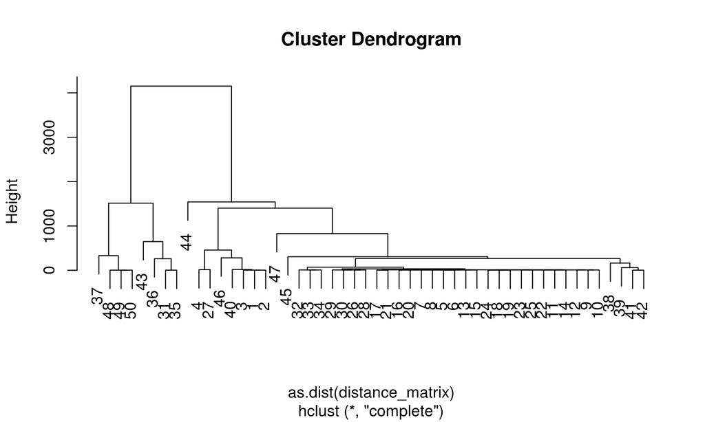

```r
plot(hc)
```

```r
# cut the projects into 2 clusters
clusters <- cutree(hc,2)
# function to examine each cluster
# input: cluster number as int, feature interested as string
# output: top 10 interested features in current cluster
top_feature <- function(cluster,feature){
  cluster_index <- which(clusters == cluster)
  colNums <- match(feature,names(short_data))

  tops <- short_data %>% filter(d_r_uuid %in% short_list[cluster_index]) %>%
    group_by(.[[colNums]]) %>% summarise(occur = n()) %>%
    arrange(desc(occur)) %>% head(10)
  names(tops)[1] <- feature
  return(tops)
}
```

```r
top_feature(1,"license_id")
```

```
## # A tibble: 10 × 2
##    license_id occur
##        <fctr> <int>
## 1          34 27309
## 2         389 26097
## 3          30 25060
## 4          87 23729
## 5          13 22901
## 6         471 22676
## 7         121 22272
## 8         375 22272
## 9          11 22010
## 10         36 21193
```

```r
top_feature(2,"license_id")
```

```
## # A tibble: 9 × 2
##   license_id occur
##       <fctr> <int>
## 1         45 20926
## 2         34  6458
## 3         11  5637
## 4         30  5637
## 5         22  3711
## 6         31  3711
## 7         12  2747
## 8          3  1926
## 9        175  1926
```

```r
top_feature(1,"dns")
```

```
## # A tibble: 10 × 2
##                                 dns occur
##                              <fctr> <int>
## 1  eef1ddca51de16bb21dcc01fef368f20 31217
## 2  68d0069599b0ce7abacfd247e0be1f0a 20976
## 3  adf13963b184fb55b5618e58119a9d89 20805
## 4  f1910a70a8fa137ab3f9e53ca3e0a6cf 19912
## 5  731fc518729b393cb9ff5395275b18e4 11020
## 6  c52e1f5415f3b248331dbd72f4cacba9 10640
## 7  e55c7fc919bbe013837ced113c3bcaec 10640
## 8  9305ac765b1b39fd982ee136332e89e5 10602
## 9  bb554ca9e4f43d11dc9df36c599c30fd 10602
## 10 0d5c1b2c6694ffe825b5d63fb55f46e4 10583
```

```r
top_feature(2,"dns")
```

```
## # A tibble: 10 × 2
##                                 dns occur
##                              <fctr> <int>
## 1  3fe69f7a8cbe753e2a1d92bee203c4f3   490
## 2  f7e78f762ddad551744108c7220b7730   356
## 3  32806adbfdd673c2dda6d4392d07d479   245
## 4  2fb63cdc2710e8e1ed1574134ff8951a   194
## 5  5e34338d479856750005e53e88dc03cd   194
## 6  7edc81be696c8864876da26a262af41f   192
## 7  520fd36f45854dc524b94e6c5e17ba28   170
## 8  8b1ce2e654d3e351a127ddc0759fc36a   170
## 9  3c8f7a9e4002c7e2d2375ab3cc7ba5ce   168
## 10 ec3bac11e1e6febda5b2409c09124db2   154
```

```r
top_feature(1,"version")
```

```
## # A tibble: 10 × 2
##        version occur
##         <fctr> <int>
## 1        5.0.1 52041
## 2        4.4.4 52003
## 3        4.3.3 48184
## 4     8u72-b15 46680
## 5   7u85-2.6.1 32571
## 6        5.0.2 26676
## 7    5.0.1~rc2 26505
## 8    4.4.2~rc1 25669
## 9        4.4.2 25479
## 10 6b18-1.8.13 22784
```

```r
top_feature(1,"version")
```

```
## # A tibble: 10 × 2
##        version occur
##         <fctr> <int>
## 1        5.0.1 52041
## 2        4.4.4 52003
## 3        4.3.3 48184
## 4     8u72-b15 46680
## 5   7u85-2.6.1 32571
## 6        5.0.2 26676
## 7    5.0.1~rc2 26505
## 8    4.4.2~rc1 25669
## 9        4.4.2 25479
## 10 6b18-1.8.13 22784
```

## Thank You!

[figure not shown]